# ÉVALUATION EMPIRIQUE DU LIEN ENTRE TAUX DE CHANGE ET POLITIQUE MONÉTAIRE

Thi Hoang Ha DO / Fidan AGHAYEVA

2026-04-09

### Import libraries

```r
rm(list = ls())
library(readr)
library(dplyr)
library(tidyr)
library(forecast)
library(tseries)
library(ggplot2)
library(stargazer)
library(lmtest)
library(lubridate)
library(corrplot)
```

### Données

Donnée du taux de change EUR/USD et de taux d’intérêt de 2004 à 2025 :

```r
data_raw <- read_csv("Econometrics/data/base_eurusd_weekly.csv", show_col_types = FALSE) %>% mutate(date = as.Date(date, format = "%Y-%m-%d"))
print(head(data_raw))
```

```
## # A tibble: 6 × 8
##   date       eurusd ct_us mt_us lt_us ct_eur mt_eur lt_eur
##   <date>      <dbl> <dbl> <dbl> <dbl>  <dbl>  <dbl>  <dbl>
## 1 2004-09-10   1.22  1.63  2.52  4.21   2.03   2.59   4.12
## 2 2004-09-17   1.22  1.65  2.49  4.14   2.05   2.59   4.10
## 3 2004-09-24   1.23  1.69  2.53  4.04   2.06   2.58   4.04
## 4 2004-10-01   1.23  1.69  2.6   4.1    2.06   2.57   4.09
## 5 2004-10-08   1.23  1.68  2.67  4.2    2.04   2.50   4.03
## 6 2004-10-15   1.24  1.7   2.53  4.08   2.06   2.43   3.98
```

```r
print(paste("Data from ", format(min(data_raw$date), "%Y-%m-%d"), " to ", format(max(data_raw$date), "%Y-%m-%d")))
```

```
## [1] "Data from  2004-09-10  to  2025-12-19"
```

```r
data <- data_raw
```

Le taux court terme du dollar est présenté par **US 3M Treasury Bill**.

Le taux moyen terme du dollar est présenté par **US 2Y Treasury Bond**.

Le taux long terme du dollar est présenté par **US 10Y Treasury Bond**.

Le taux court terme de l’euro est présenté par **3M Spot rate Euro area Government Bonds**.

Le taux moyen terme de l’euro est présenté par **2Y Spot rate Euro area Government Bonds**.

Le taux long terme de l’euro est présenté par **10Y Spot rate Euro area Government Bonds**.

# Partie 1: Préambule

On réalise le test ADF (Augmented Dickey-Fuller) pour vérifier la stationnarité de la série temporelle des taux de change EUR/USD, et de la série temporelle des différences premières de taux de change EUR/USD.

```r
# ADF test on EUR/USD exchange rate
adf.test(data$eurusd)
```

```
##
##  Augmented Dickey-Fuller Test
##
## data:  data$eurusd
## Dickey-Fuller = -2.9324, Lag order = 10, p-value = 0.1836
## alternative hypothesis: stationary
```

```r
# ADF test on first difference of EUR/USD exchange rate
data$diff_eurusd <- (data$eurusd - lag(data$eurusd)) / lag(data$eurusd)
adf.test(na.omit(data$diff_eurusd))
```

```
##
##  Augmented Dickey-Fuller Test
##
## data:  na.omit(data$diff_eurusd)
## Dickey-Fuller = -9.6161, Lag order = 10, p-value = 0.01
## alternative hypothesis: stationary
```

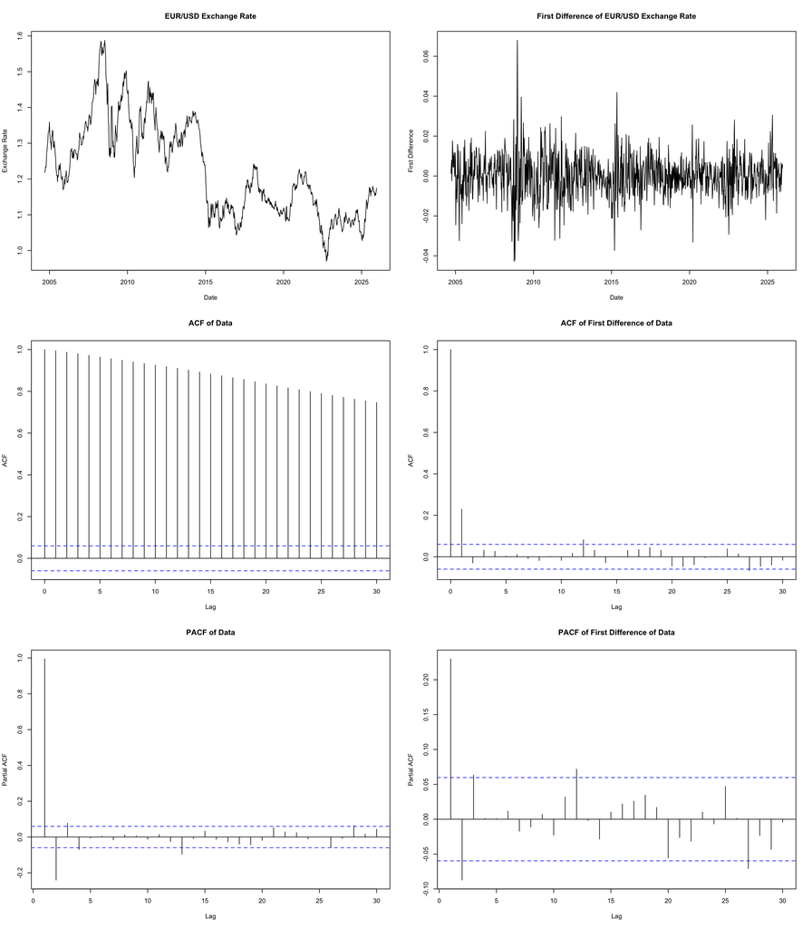

```r
#Calculer ACF et PACF de la série temporelle
layout(matrix(c(1, 2, 3, 4, 5, 6), nrow = 3, byrow = TRUE))
plot(data$date, data$eurusd, type = "l", main = "EUR/USD Exchange Rate", xlab = "Date", ylab = "Exchange Rate")
plot(data$date, data$diff_eurusd, type = "l", main = "First Difference of EUR/USD Exchange Rate", xlab = "Date", ylab = "First Difference")
acf(data$eurusd, main = "ACF of Data")
acf(na.omit(data$diff_eurusd), main = "ACF of First Difference of Data")
pacf(data$eurusd, main = "PACF of Data")
pacf(na.omit(data$diff_eurusd), main = "PACF of First Difference of Data")
```

D’après le test ADF, la série temporelle des taux de change EUR/USD n’est pas stationnaire, car le p-value est supérieur à 0.05.

Cependant, la série temporelle des différences premières de taux de change EUR/USD est stationnaire, car le p-value est inférieur à 0.05.

On va estimer des modèles ARMA(p,q) pour les deux séries temporelles, pour voir si le modèle ARMA(p,q) peut capturer la dynamique de la série des taux de change EUR/USD, même si la série temporelle n’est pas stationnaire, et pour voir si le modèle ARMA(p,q) peut capturer la dynamique de la série des différences premières de taux de change EUR/USD, qui est stationnaire.

## Partie 1.1: Fit ARMA(p,q) model

Identifier et estimer un modèle ARMA(p,q) pour la série temporelle des taux de change:

$$\Phi(L)y_{(i,j),t} = \alpha + \Theta(L)u_t$$

On utilise les critères AIC et BIC pour sélectionner le meilleur modèle ARMA(p,q).

### Partie 1.1.1: Fit ARMA(p,q) model pour la série temporelle des taux de change EUR/USD

Dans cette partie, on utilise la série temporelle des taux de change EUR/USD pour estimer le modèle ARMA(p,q), même si la série temporelle n’est pas stationnaire, pour voir si le modèle ARMA(p,q) peut capturer la dynamique de la série temporelle des taux de change EUR/USD.

On essaie à trouver le meilleur couple de p et q pour le modèle ARMA(p,q) en utilisant les critères AIC et BIC, avec p et q allant de 0 à 10.

```r
par(mfrow = c(1, 1))
p_max <- 10
q_max <- 10
results <- data.frame(p = integer(), q = integer(), AIC = numeric(), BIC = numeric())
k <- 1
for (p in 0:p_max) {
    for (q in 0:q_max) {
        fit <- try(arima(data$eurusd, order = c(p, 0, q)), silent = TRUE)
        if (class(fit) != "try-error") {
            results[k, ] <- data.frame(p = p, q = q, AIC = AIC(fit), BIC = BIC(fit))
        }
        k <- k + 1
    }
}

table_results <- do.call(rbind, lapply(1:nrow(results), function(i) {
    if (!is.na(results$AIC[i]) & !is.na(results$BIC[i])) {
        data.frame(p = results$p[i], q = results$q[i], AIC = results$AIC[i], BIC = results$BIC[i])
    }
}))

# Find minimum values for AIC and BIC
table_results <- table_results %>% drop_na()
table_results$delta_BIC <- table_results$BIC - min(table_results$BIC)
table_results$delta_AIC <- table_results$AIC - min(table_results$AIC)
table_AIC <- table_results[order(table_results$AIC), ]
table_BIC <- table_results[order(table_results$BIC), ]
cat("Top 5 models based on AIC:\n")
```

```
## Top 5 models based on AIC:
```

```r
print(head(table_AIC, 5))
```

```
##    p q       AIC       BIC delta_BIC delta_AIC
## 78 7 2 -6373.462 -6318.650 34.503629 0.0000000
## 67 6 2 -6373.189 -6323.361 29.793508 0.2727421
## 13 1 1 -6373.086 -6353.154  0.000000 0.3764101
## 24 2 1 -6372.347 -6347.432  5.721819 1.1153661
## 44 4 0 -6372.301 -6342.404 10.750492 1.1611768
```

```r
cat("\nTop 5 models based on BIC:\n")
```

```
##
## Top 5 models based on BIC:
```

```r
print(head(table_BIC, 5))
```

```
##    p q       AIC       BIC delta_BIC delta_AIC
## 13 1 1 -6373.086 -6353.154  0.000000 0.3764101
## 24 2 1 -6372.347 -6347.432  5.721819 1.1153661
## 14 1 2 -6372.196 -6347.282  5.872020 1.2655671
## 23 2 0 -6364.145 -6344.213  8.940853 9.3172628
## 34 3 0 -6368.983 -6344.069  9.085413 4.4789603
```

La meilleure modèle ARMA(p,q) basé sur BIC est ARMA(1,1) avec AIC = -6373.086 et BIC = -6353.154, basé sur AIC est ARMA(7, 2) avec AIC = -6373.462 et BIC = -6318.650. AIC a tendance à surestimer la taile du modèle, ce qui implique une couple p et q très grande, et donc augmente le risque d’overfitting. On préfère donc choisir le modèle ARMA(1,1) basé sur BIC, car il pénalise plus les modèles avec plus de paramètres, ce qui évite l’overfitting. On a donc choisi le modèle ARMA(1,1) pour la suite de l’analyse.

$$y_{(i,j),t} = \alpha + \phi_1 y_{(i,j),t-1} + \theta_1 u_{t-1} + u_t$$

```r
best_model_arma <- table_BIC[1, ]
cat("Best model : ARMA(", best_model_arma$p, ",", best_model_arma$q, ")\n")
```

```
## Best model : ARMA( 1 , 1 )
```

```r
fit_arma <- arima(data$eurusd, order = c(best_model_arma$p, 0, best_model_arma$q), include.mean = TRUE, method = "ML")
summary(fit_arma)
```

```
##
## Call:
## arima(x = data$eurusd, order = c(best_model_arma$p, 0, best_model_arma$q), include.mean = TRUE,
##     method = "ML")
##
## Coefficients:
##          ar1     ma1  intercept
##       0.9918  0.2774     1.2251
## s.e.  0.0036  0.0306     0.0538
##
## sigma^2 estimated as 0.0001566:  log likelihood = 3190.54,  aic = -6373.08
##
## Training set error measures:
##                         ME       RMSE         MAE         MPE      MAPE
## Training set -2.787177e-05 0.01251538 0.009269579 -0.01291892 0.7514794
##                   MASE         ACF1
## Training set 0.9679309 -0.008239787
```

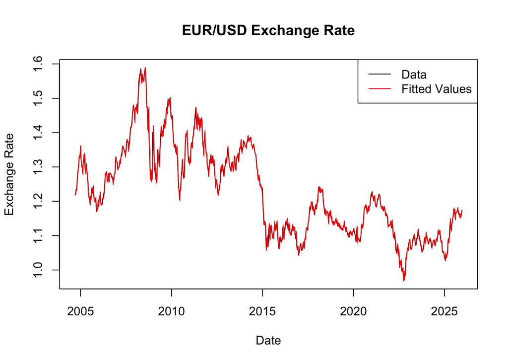

```r
par(mfrow = c(1, 1))
plot(data$date, data$eurusd, type = "l", main = "EUR/USD Exchange Rate", xlab = "Date", ylab = "Exchange Rate", col = "black")
lines(data$date, fitted(fit_arma), col = "red")
legend("topright", legend = c("Data", "Fitted Values"), col = c("black", "red"), lty = 1)
```

```r
par(mfrow = c(1, 1))
```

Notre paramètres de ARMA(1,1) sont
$$\phi_1 = 0.9918
\\
\theta_1 = 0.2774
\\
\alpha = 1.2251$$

La formule de ARMA(1,1) est
$$y_{(i,j),t} = 1.2251 + 0.9918 y_{(i,j),t-1} + 0.2774 u_{t-1} + u_t$$

$abs(\phi_1)$ < 1, donc le modèle ARMA(1,1) est stationnaire et inversible. $abs(\theta_1)$ < 1, donc le modèle ARMA(1,1) est inversible.

$\phi_1$ est très proche de 1, ce qui suggère que la série temporelle des taux de change EUR/USD présente une forte persistance, et que les valeurs passées ont un impact significatif sur les valeurs futures.

### Partie 1.1.2: Fit ARMA(p,q) model pour la série temporelle des différences premières de taux de change EUR/USD

Dans cette partie, on utilise la série temporelle des différences premières de taux de change EUR/USD pour estimer le modèle ARMA(p,q), car la série temporelle des différences premières de taux de change EUR/USD est stationnaire.

```r
par(mfrow = c(1, 1))

p_max <- 10
q_max <- 10
results_AIC_BIC_diff <- data.frame(p = integer(), q = integer(), AIC = numeric(), BIC = numeric())
k <- 1
for (p in 0:p_max) {
    for (q in 0:q_max) {
        fit <- try(arima(na.omit(data$diff_eurusd), order = c(p, 0, q)), silent = TRUE)
        if (class(fit) != "try-error") {
            results_AIC_BIC_diff[k, ] <- data.frame(p = p, q = q, AIC = AIC(fit), BIC = BIC(fit))
        }
        k <- k + 1
    }
}

table_results_diff <- do.call(rbind, lapply(1:nrow(results_AIC_BIC_diff), function(i) {
    if (!is.na(results_AIC_BIC_diff$AIC[i]) & !is.na(results_AIC_BIC_diff$BIC[i])) {
        data.frame(p = results_AIC_BIC_diff$p[i], q = results_AIC_BIC_diff$q[i], AIC = results_AIC_BIC_diff$AIC[i], BIC = results_AIC_BIC_diff$BIC[i])
    }
}))
# Find minimum values for AIC and BIC
table_results_diff <- table_results_diff %>% drop_na()
table_results_diff$delta_BIC <- table_results_diff$BIC - min(table_results_diff$BIC)
table_results_diff$delta_AIC <- table_results_diff$AIC - min(table_results_diff$AIC)
table_AIC_diff <- table_results_diff[order(table_results_diff$AIC), ]
table_BIC_diff <- table_results_diff[order(table_results_diff$BIC), ]
cat("Top 5 models (1st differences data) based on AIC:\n")
```

```
## Top 5 models (1st differences data) based on AIC:
```

```r
print(head(table_AIC_diff, 5))
```

```
##    p q       AIC       BIC delta_BIC  delta_AIC
## 13 1 1 -6857.886 -6837.958  4.891857 0.00000000
## 2  0 1 -6857.796 -6842.850  0.000000 0.09007794
## 3  0 2 -6857.735 -6837.807  5.042459 0.15060259
## 34 3 0 -6857.035 -6832.125 10.724400 0.85060868
## 42 3 8 -6856.650 -6791.884 50.965498 1.23622920
```

```r
cat("\nTop 5 models (1st differences data) based on BIC:\n")
```

```
##
## Top 5 models (1st differences data) based on BIC:
```

```r
print(head(table_BIC_diff, 5))
```

```
##    p q       AIC       BIC delta_BIC  delta_AIC
## 2  0 1 -6857.796 -6842.850  0.000000 0.09007794
## 13 1 1 -6857.886 -6837.958  4.891857 0.00000000
## 3  0 2 -6857.735 -6837.807  5.042459 0.15060259
## 23 2 0 -6854.698 -6834.770  8.079703 3.18784662
## 12 1 0 -6848.468 -6833.522  9.327693 9.41777117
```

```r
# Fit the best model based on BIC
best_model_diff_arma <- table_BIC_diff[1, ]
cat("Best model for 1st differences data : ARMA(", best_model_diff_arma$p, ",", best_model_diff_arma$q, ")\n")
```

```
## Best model for 1st differences data : ARMA( 0 , 1 )
```

```r
fit_arma_diff <- arima(data$diff_eurusd, order = c(best_model_diff_arma$p, 0, best_model_diff_arma$q), include.mean = TRUE, method = "ML")
summary(fit_arma_diff)
```

```
##
## Call:
## arima(x = data$diff_eurusd, order = c(best_model_diff_arma$p, 0, best_model_diff_arma$q),
##     include.mean = TRUE, method = "ML")
##
## Coefficients:
##          ma1  intercept
##       0.2668      0e+00
## s.e.  0.0308      4e-04
##
## sigma^2 estimated as 9.993e-05:  log likelihood = 3431.9,  aic = -6857.8
##
## Training set error measures:
##                        ME        RMSE         MAE MPE MAPE     MASE        ACF1
## Training set 7.342858e-07 0.009996628 0.007506788 NaN  Inf 0.781575 -0.01145083
```

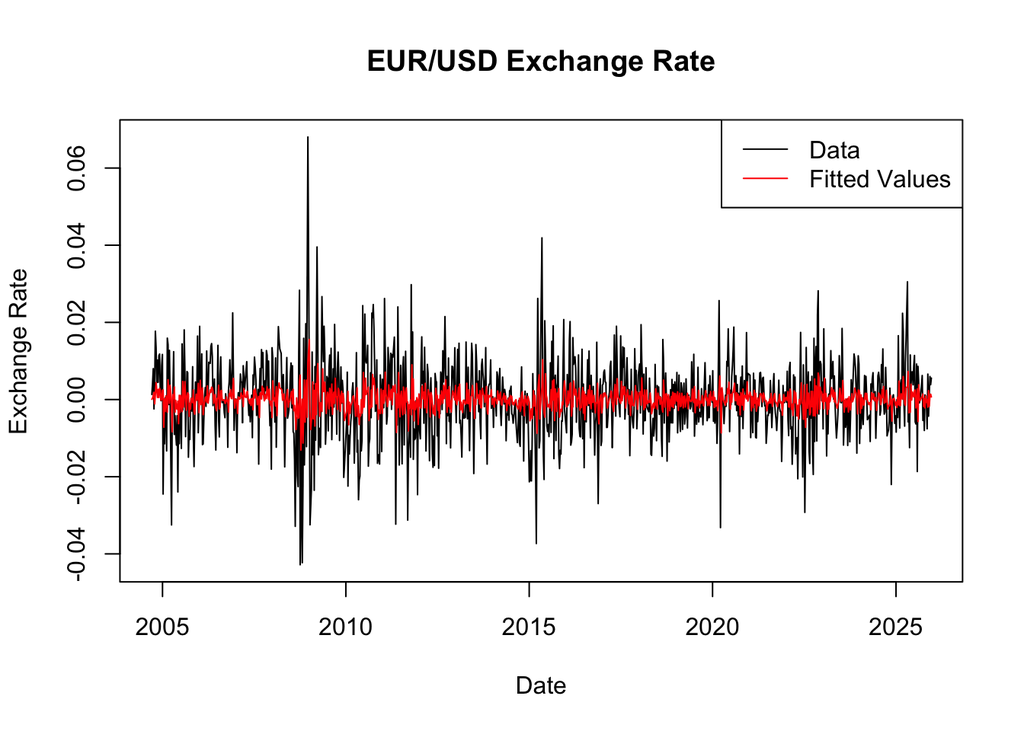

```r
par(mfrow = c(1, 1))
plot(data$date, data$diff_eurusd, type = "l", main = "EUR/USD Exchange Rate", xlab = "Date", ylab = "Exchange Rate", col = "black")
lines(data$date, fitted(fit_arma_diff), col = "red")
legend("topright", legend = c("Data", "Fitted Values"), col = c("black", "red"), lty = 1)
```

```r
par(mfrow = c(1, 1))
```

En utilisant la série temporelle des différences premières de taux de change EUR/USD, le meilleur modèle ARMA(p,q) basé sur BIC est ARMA(0,1).
$$\delta y_{(i,j),t} = u_t + \theta_1 u_{t-1}$$

Ce résultat est cohérent avec l’estimation d’un ARMA(1,1) sur la série temporelle des taux de change EUR/USD, qui produit un coefficient de AR(1) très proche de 1, ce qui suggère que la série temporelle des taux de change EUR/USD présente une forte persistance, et que les valeurs passées (de décalage 1) ont un impact significatif sur les valeurs futures.

On peut donc utiliser la modèle ARMA(1,1) pour la série temporelle des taux de change EUR/USD pour faire le diagnostic du modèle et le forecast.

## Partie 1.2: Tests de modèle

Afin de diagnostiquer le modèle, on doit tester sur les coefficients et les résidus du modèle, pour assurer que le modèle est bien spécifié et que les résidus ont de moyenne 0 avec variance constante.

Concernant les résidus, il faut effectuer trois tests pour vérifier les résidus du modèle ARMA(1,1) : Le premier concerne l’autocorrélation des résidus, le second concerne la constance de la variance des résidus (hétéroscédasticité), et le troisième concerne la normalité des résidus.

### Test pour l’autocorrélation des résidus

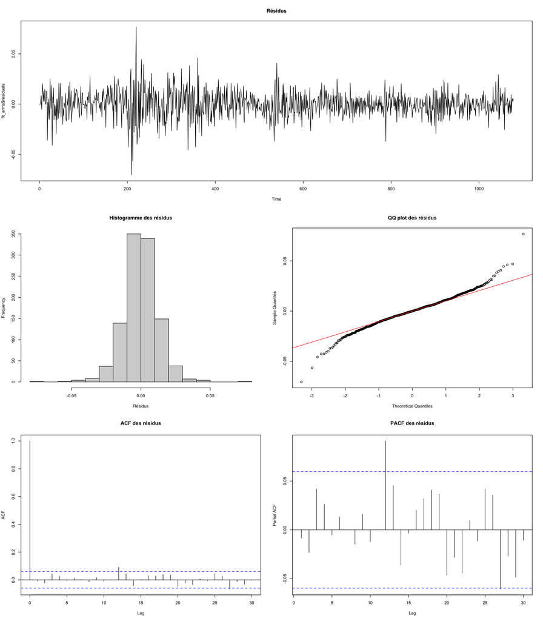

```r
# Validation du modèle
layout(matrix(c(1, 1, 2, 3, 4, 5), nrow = 3, byrow = TRUE))
plot(fit_arma$residuals, main = "Résidus", type = "l")
hist(fit_arma$residuals, main = "Histogramme des résidus", xlab = "Résidus")
qqnorm(fit_arma$residuals, main = "QQ plot des résidus"); qqline(fit_arma$residuals, col = "red")
acf(fit_arma$residuals, main = "ACF des résidus")
pacf(fit_arma$residuals, main = "PACF des résidus")
```

### Test d’effet ARCH : pour hétéroscédasticité (test si la variance des résidus est constante)

```r
par(mfrow = c(1, 1))
Box.test(fit_arma$residuals^2, lag = 20, type = "Ljung-Box")
```

```
##
##  Box-Ljung test
##
## data:  fit_arma$residuals^2
## X-squared = 736.08, df = 20, p-value < 2.2e-16
```

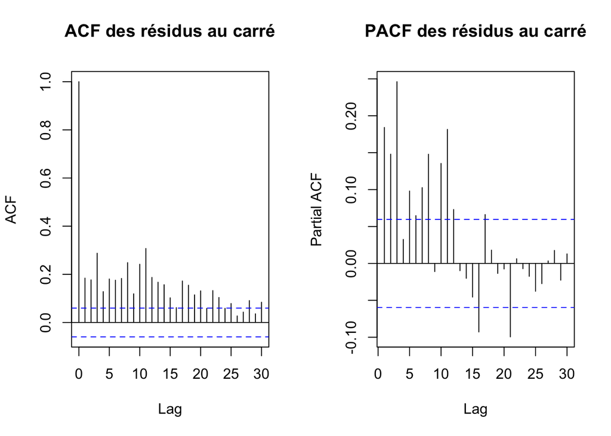

```r
# Plot ACF et PACF des résidus au carré
par(mfrow = c(1, 2))
acf(fit_arma$residuals^2, main = "ACF des résidus au carré")
pacf(fit_arma$residuals^2, main = "PACF des résidus au carré")
```

H0: variance des résidus est constante (pas d’effet ARCH)

H1: variance des résidus n’est pas constante (il existe un effet ARCH)

On a : p-value < 0.05, on rejette donc l’hypothèse nulle d’absence d’autocorrélation des résidus au carré. Les résidus au carré donc ne sont pas stationnaires, il existe une hétéroscédasticité conditionnelle dans les résidus du modèle ARMA(1,1). Le modèle ARMA(1,1) est donc biaisé.

### Test de Jarque-Bera pour la normalité des résidus

```r
par(mfrow = c(1, 1))
jarque.bera.test(fit_arma$residuals)
```

```
##
##  Jarque Bera Test
##
## data:  fit_arma$residuals
## X-squared = 452.88, df = 2, p-value < 2.2e-16
```

Pour le test Jarque-Bera, p-value < 0.05, on donc rejette l’hypothèse nulle de normalité des résidus. Avec ce test, il signifie que les résidus du modèle ARMA(1,1) ne suivent pas une distribution normale.

## Forecast en utilisant le modèle ARMA(1,1)

On utilise 100% des observations pour estimer le modèle ARMA(1,1), et on fait un forecast pour les 52 prochaines semaines (1 an). Comme la modèle est ARMA(1,1), après le 1er forecast, l’effet de MA disparaît, et le forecast devient une fonction de AR(1) seulement. En Première 52 semaines (1 an), le forecast montre une tendance à la hausse du taux de change EUR/USD.

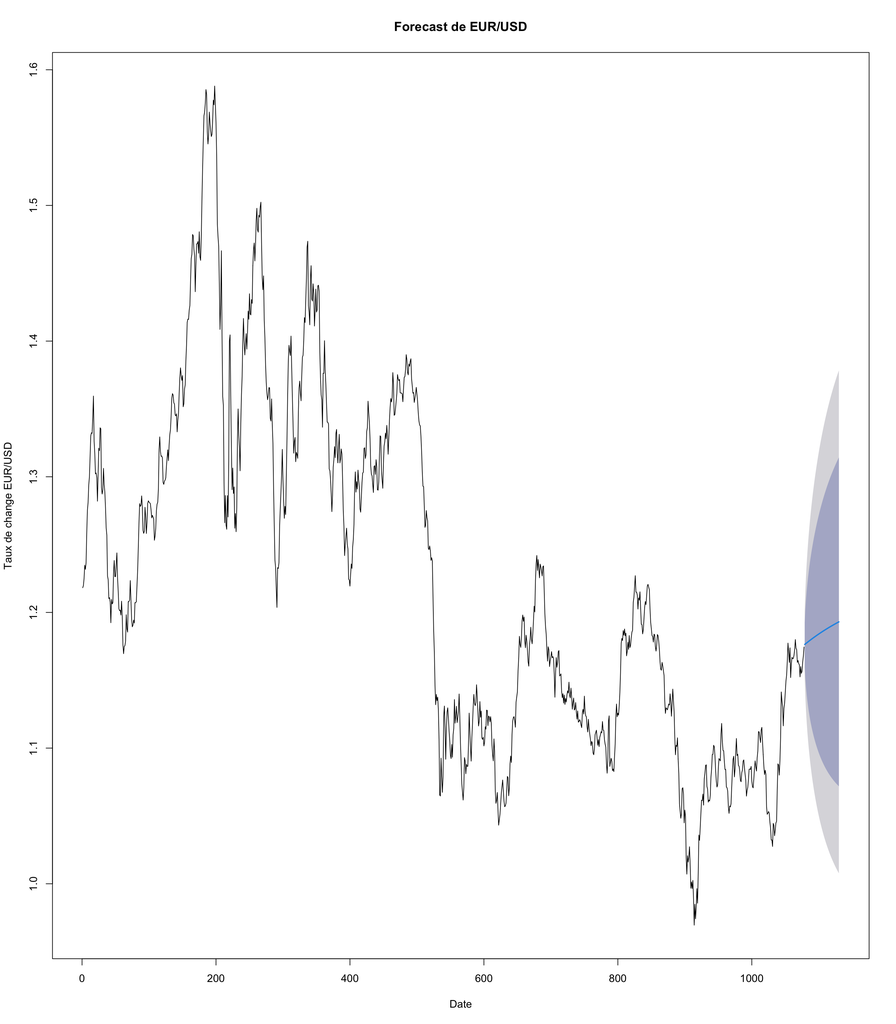

```r
horizon <- 52 # Forecast pour les 52 prochaines semaines
forecast_change <- forecast(fit_arma, h = horizon)
plot(forecast_change, main = "Forecast de EUR/USD", xlab = "Date", ylab = "Taux de change EUR/USD")
```

### Forecast en utilisant split de données

Dans cette partie, on utilise 70% des observations pour estimer le modèle ARMA(1,1), et on utilise les 30% restantes pour évaluer la performance du modèle.

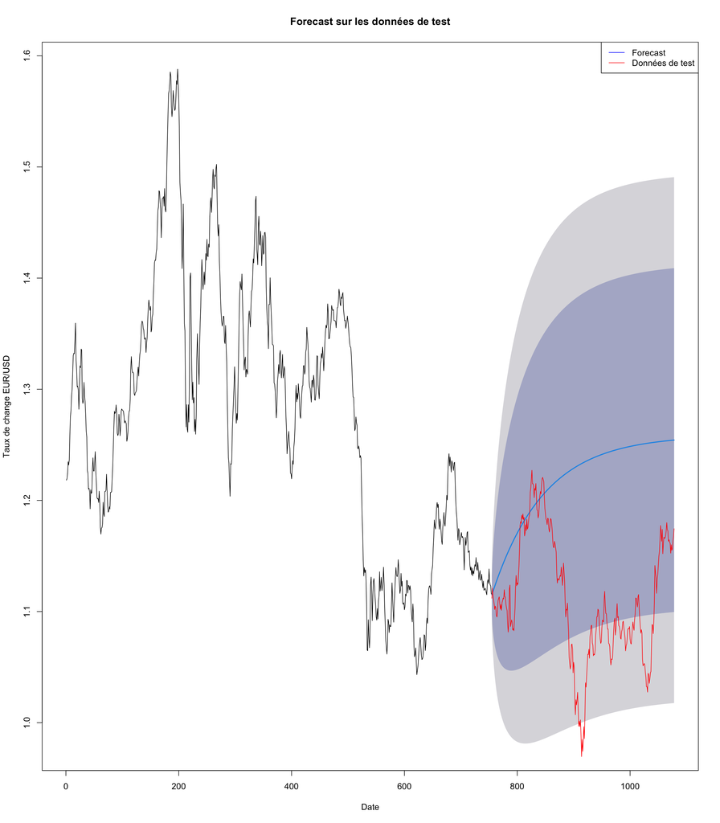

```r
length_data <- length(data$eurusd)
train_percent <- 0.7
train_data <- data$eurusd[1:floor(train_percent * length_data)]
test_data <- data$eurusd[(floor(train_percent * length_data) + 1):length_data]

fit_arma_train <- arima(train_data, order = c(best_model_arma$p, 0, best_model_arma$q), include.mean = TRUE, method = "ML")
forecast_train <- forecast(fit_arma_train, h = length(test_data))
train_end <- floor(train_percent * length_data)
test_index <- (train_end + 1):length_data

plot(forecast_train, main = "Forecast sur les données de test", xlab= "Date", ylab = "Taux de change EUR/USD")
lines(test_index, test_data, col = "red")
legend("topright", legend = c("Forecast", "Données de test"), col = c("blue", "red"), lty = 1)
```

### Conclusion de la partie 1:

Le modèle ARMA(1,1) est choisi comme le meilleur modèle pour la série temporelle des taux de change EUR/USD, avec des résidus présentent une hétéroscédasticité conditionnelle.

Le modèle semble naif pour la prévision à long terme, en plus l’hétéroscédasticité suggère que le modèle ARMA(1,1) peut ne pas capturer toute la dynamique temporelle présente dans les données, et il peut être nécessaire d’ajouter des autres termes pour améliorer la spécification du modèle.

# Partie 2: Différentiel de taux d’intérêt entre l’Euro et le Dollar

### Réprésentation graphique du taux de change EUR/USD et les différentiels de taux d’intérêt entre l’Euro et le Dollar

Dans cette partie, on calcule les différentiels de taux d’intérêt à court terme, moyen terme et long terme entre le Dollar et l’Euro, et on présente graphiquement le taux de change EUR/USD et les différentiels de taux d’intérêt sur la même période.

```r
data <- data_raw %>%
    mutate(
        # Short-term interest rate differential
        diff_st = ct_us - ct_eur,
        # Medium-term interest rate differential
        diff_mt = mt_us - mt_eur,
        # Long-term interest rate differential
        diff_lt = lt_us - lt_eur
    )
```

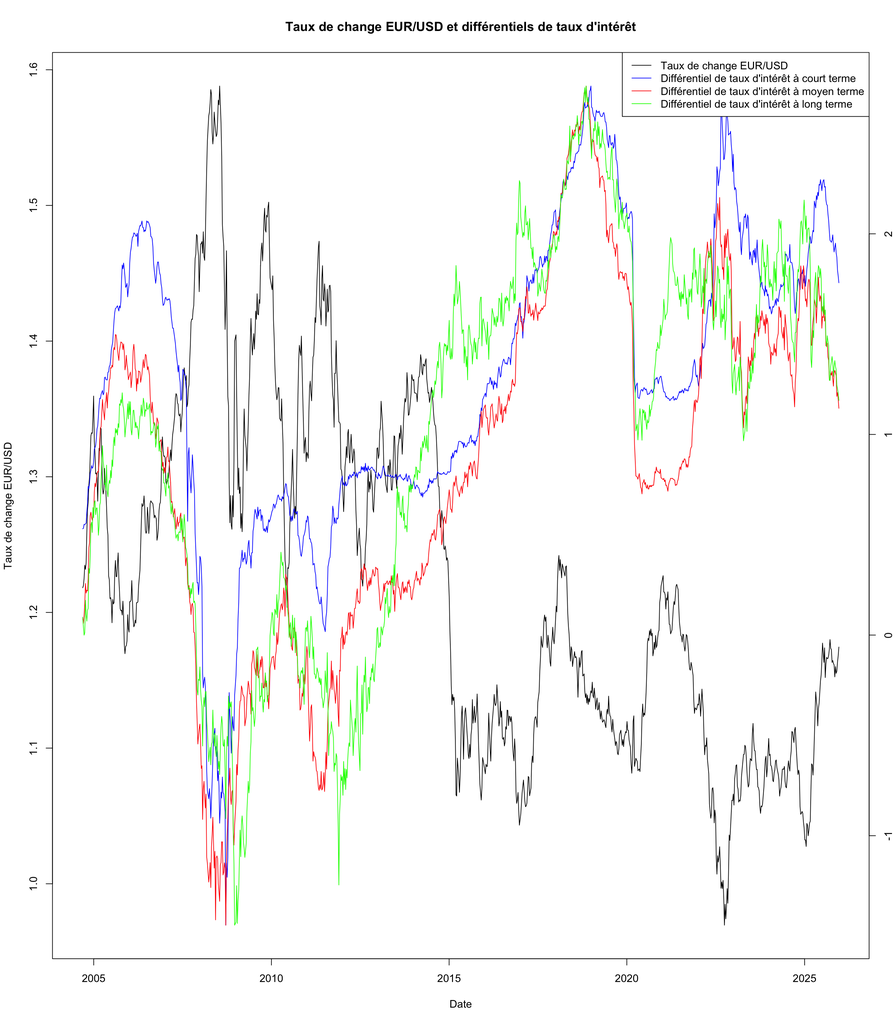

```r
par(mfrow = c(1, 1))
plot(data$date, data$eurusd, type = "l", main = "Taux de change EUR/USD et différentiels de taux d'intérêt", xlab = "Date", ylab = "Taux de change EUR/USD", col = "black")
par(new = TRUE)
plot(data$date, data$diff_st, type = "l", main = "", xlab = "", ylab = "", col = "blue", axes = FALSE)
par(new = TRUE)
plot(data$date, data$diff_mt, type = "l", main = "", xlab = "", ylab = "", col = "red", axes = FALSE)
par(new = TRUE)
plot(data$date, data$diff_lt, type = "l", main = "", xlab = "", ylab = "", col = "green", axes = FALSE)
axis(side = 4)
mtext(side = 4, line = 4, "Différentiel de taux d'intérêt")
legend("topright", legend = c("Taux de change EUR/USD", "Différentiel de taux d'intérêt à court terme", "Différentiel de taux d'intérêt à moyen terme", "Différentiel de taux d'intérêt à long terme"), col = c("black", "blue", "red", "green"), lty = 1)
```

### Matrice de corrélation entre les taux de change et les différentiels de taux d’intérêt

On génère une matrice de corrélation pour évaluer la relation entre les taux de change EUR/USD et les différentiels de taux d’intérêt à court terme, moyen terme et long terme.

```r
cor_matrix <- cor(data.frame(eurusd = data$eurusd, diff_st = data$diff_st, diff_mt = data$diff_mt, diff_lt = data$diff_lt))
print(cor_matrix)
```

```
##             eurusd    diff_st    diff_mt    diff_lt
## eurusd   1.0000000 -0.7547103 -0.8120527 -0.7889543
## diff_st -0.7547103  1.0000000  0.9519490  0.8169419
## diff_mt -0.8120527  0.9519490  1.0000000  0.9084366
## diff_lt -0.7889543  0.8169419  0.9084366  1.0000000
```

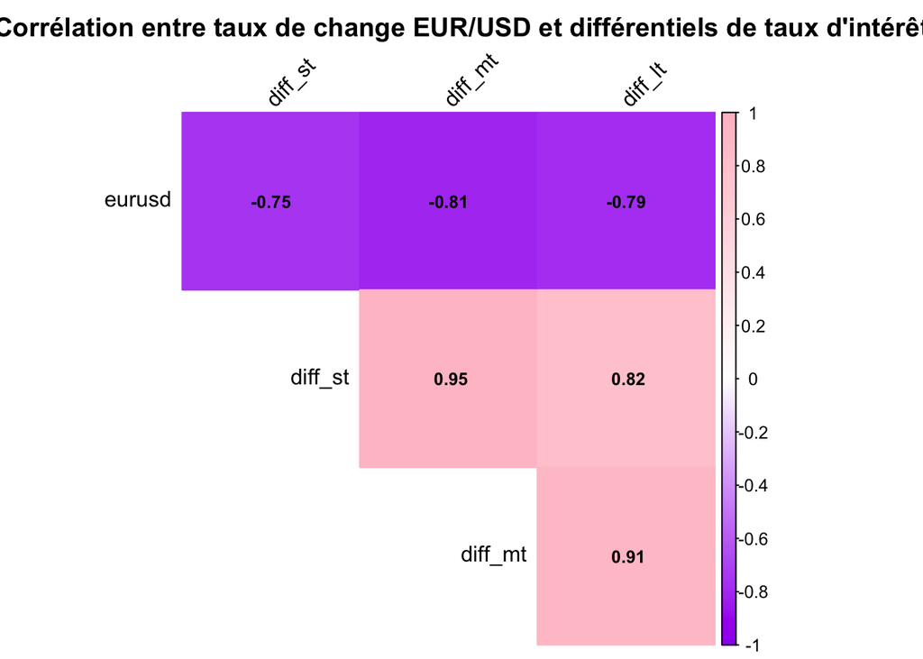

```r
corrplot(
    cor_matrix,
    method = "color",
    type = "upper",
    col = colorRampPalette(c("purple", "white", "pink"))(200),
    tl.col = "black",
    tl.srt = 45,
    addCoef.col = "black",
    number.cex = 0.8,
    diag = FALSE,
    title = "Corrélation entre taux de change EUR/USD et différentiels de taux d'intérêt",
    mar = c(0, 0, 2, 0)
)
```

Les corrélations entre taux de change EUR/USD et différentiels de taux d’intérêt sont négatives, qui sont -0.755, -0.812 et -0.789 respectivement pour les différentiels de taux d’intérêt à court terme, moyen terme et long terme.

Ce résultat indique que lorsque le taux de change EUR/USD augmentent, les différentiels de taux d’intérêt tendent à diminuer. Une hausse de taux d’intérêt dans aux Etats-Unis implique donc une appréciation de l’usd par rapport à l’euro (EUR/USD diminue).

D’après la parité des taux d’intérêt non couverte, lorsque le taux d’intérêt domestique augmente, on anticipe une dépréciation de la monnaie domestique, ce qui est incohérent avec les résultats de corrélation négative entre les taux de change EUR/USD et les différentiels de taux d’intérêt.

Ce résultat n’est pas surprise car empiriquemennt, la PTINC est souvent violée, en raison de l’existence de primes de risque, des comportements spéculatifs et/ou irrationnels, et des restrictions de ccapitaux dans certains pays.

La stratégie de carry trade, qui consiste à emprunter dans une monnaie à faible taux d’intérêt et investir dans une monnaie à taux d’intérêt plus élevé, est un exemple de violation de la PTINC. Cette stratégie consiste à prêter de l’argent dans une monnaie à faible taux d’intérêt et investir dans une monnaie à taux d’intérêt plus élevé, tant que la monnaie à taux d’intérêt plus élevé s’apprécie, et la monnaie à faible taux d’intérêt se déprécie, les investisseurs peuvent réaliser un profit.

Dans un environnement de marché stable, cette stratégie peut être rentable, mais elle comporte également des risques importants, notamment en cas de volatilité du marché ou de changements soudains dans les taux d’intérêt comme ce qui s’est passé pendant la crise financière de 2008, où de nombreux investisseurs ont subi des pertes importantes en raison de la dépréciation rapide de la monnaie à taux d’intérêt plus élevé, ou plus récent en 2025-2026, quand le Yen, qui est souvent considéré comme une monnaie à faible taux d’intérêt, s’est apprécié par rapport au dollar américain.

### Corrélation Glissante

On crée une fonctionne pour calculer la corrélation glissantes entre les taux de change EUR/USD et les différentiels de taux d’intérêt, avec la fenêtre de la période glissante comme paramètre d’entrée.

```r
rolling_corr <- function(x, y, window_size) {
    n <- length(x)
    ans <- rep(NA, n)

    if (length(y) != n) {
        stop("x et y doivent avoir la même longueur")
    }
    if (window_size < 0 || window_size >= n) {
        stop("La taille de la fenêtre doit être comprise entre 0 et nombre de données - 1")
    }
    for (i in window_size:n) {
        corr <- cor(
            x[(i - window_size + 1):i],
            y[(i - window_size + 1):i]
        )
        ans[i - window_size + 1] <- corr
    }

    return(ans)
}
```

Calcul de la corrélation glissante

```r
# We are currently using weekly data
window_sizes <- c(12, 36, 52) # 3 months, 9 months, 1 year

# Rolling correlation for 1 month window
corr_st_3m <- rolling_corr(data$eurusd, data$diff_st, window_sizes[1])
corr_mt_3m <- rolling_corr(data$eurusd, data$diff_mt, window_sizes[1])
corr_lt_3m <- rolling_corr(data$eurusd, data$diff_lt, window_sizes[1])

# Rolling correlation for 9 months window
corr_st_9m <- rolling_corr(data$eurusd, data$diff_st, window_sizes[2])
corr_mt_9m <- rolling_corr(data$eurusd, data$diff_mt, window_sizes[2])
corr_lt_9m <- rolling_corr(data$eurusd, data$diff_lt, window_sizes[2])

# Rolling correlation for 1 year window
corr_st_1y <- rolling_corr(data$eurusd, data$diff_st, window_sizes[3])
corr_mt_1y <- rolling_corr(data$eurusd, data$diff_mt, window_sizes[3])
corr_lt_1y <- rolling_corr(data$eurusd, data$diff_lt, window_sizes[3])
df_roll_st <- data.frame(
    date = data$date,
    corr_st_3m = corr_st_3m,
    corr_st_9m = corr_st_9m,
    corr_st_1y = corr_st_1y
)

df_roll_3m <- data.frame(
    date = data$date,
    corr_st_3m = corr_st_3m,
    corr_mt_3m = corr_mt_3m,
    corr_lt_3m = corr_lt_3m
)

df_roll_9m <- data.frame(
    date = data$date,
    corr_st_9m = corr_st_9m,
    corr_mt_9m = corr_mt_9m,
    corr_lt_9m = corr_lt_9m
)

df_roll_1y <- data.frame(
    date = data$date,
    corr_st_1y = corr_st_1y,
    corr_mt_1y = corr_mt_1y,
    corr_lt_1y = corr_lt_1y
)
```

Présentation graphique de la corrélation glissante:

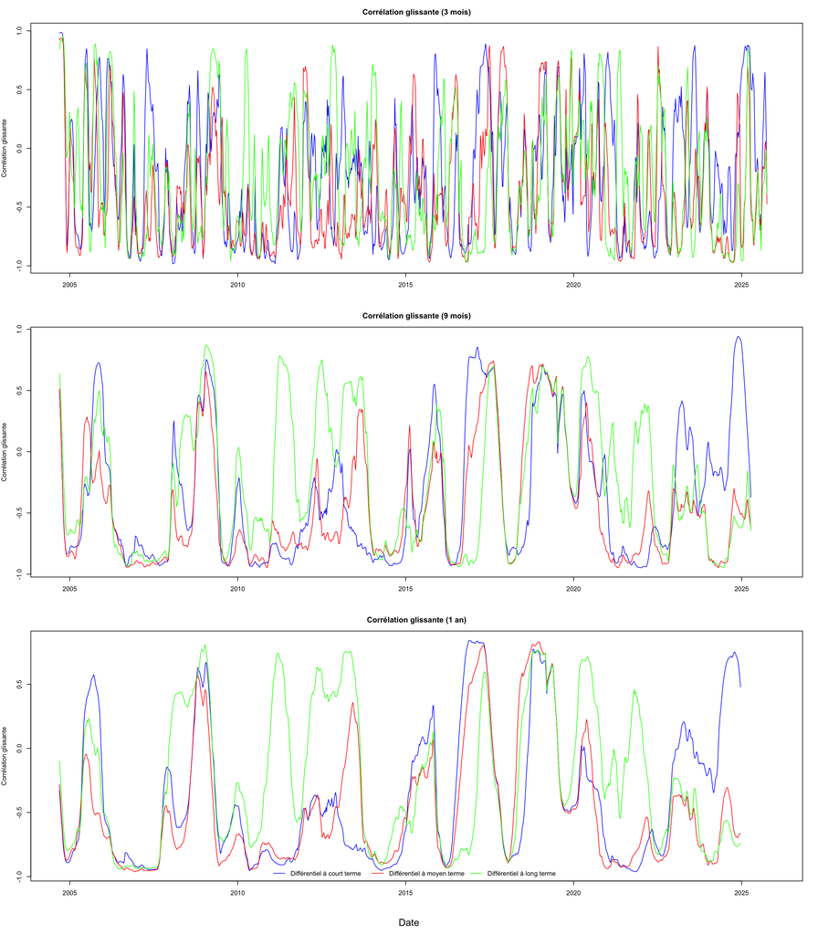

```r
par(mfrow = c(3, 1), mar = c(4, 4, 3, 2), oma = c(3, 0, 0, 0))

plot(df_roll_3m$date, df_roll_3m$corr_st_3m, type = "l", col = "blue", main = "Corrélation glissante (3 mois)", xlab = "", ylab = "Corrélation glissante")
lines(df_roll_3m$date, df_roll_3m$corr_mt_3m, col = "red")
lines(df_roll_3m$date, df_roll_3m$corr_lt_3m, col = "green")

plot(df_roll_9m$date, df_roll_9m$corr_st_9m, type = "l", col = "blue", main = "Corrélation glissante (9 mois)", xlab = "", ylab = "Corrélation glissante")
lines(df_roll_9m$date, df_roll_9m$corr_mt_9m, col = "red")
lines(df_roll_9m$date, df_roll_9m$corr_lt_9m, col = "green")

plot(df_roll_1y$date, df_roll_1y$corr_st_1y, type = "l", col = "blue", main = "Corrélation glissante (1 an)", xlab = "", ylab = "Corrélation glissante")
lines(df_roll_1y$date, df_roll_1y$corr_mt_1y, col = "red")
lines(df_roll_1y$date, df_roll_1y$corr_lt_1y, col = "green")

mtext("Date", side = 1, outer = TRUE, line = 1)

legend(
    "bottom", legend = c("Différentiel à court terme", "Différentiel à moyen terme", "Différentiel à long terme"),
    col = c("blue", "red", "green"), lty = 1, horiz = TRUE, bty = "n"
)
```

D’après les graphiques, on peut observer que : - La corrélation glissante 3 mois est très volatile, la fréquence de changement de corrélation est plus élevée que les autres fenêtres, et la corrélation peut changer de signe fréquemment.

- La corrélation glissante 9 mois est moins volatile que la corrélation glissante 3 mois, mais elle peut aussi changer de signe plusieurs fois.
- La corrélation glissante 1 an est la moins volatile, elle change de signe moins fréquemment que les autres fenêtres.

Entre les trois fenêtres, la corrélation glissante 1 an est la plus stable, tandis que la corrélation glissante 3 mois est la plus volatile.

Ce résultat est intuitif, car une fenêtre plus courte est plus sensible aux variations et/ou crises à court terme, tandis qu’une fenêtre plus longue capture mieux les tendances à long terme est moins affectée par les variations à court terme, car les fluctuations à court terme sont lissées sur une période plus longue.

# Partie 3: Modélisation en 2 étapes

## Partie 3.1: Modèle Linéaire

Nous utilisons méthode Moindres Carrés Ordinaires (OLS) pour estimer la modèle linéaire entre les taux de change EUR/USD et les différentiels de taux d’intérêt à court terme, moyen terme et long terme.

$$y_{(i,j),t} = \alpha_1 + \beta_1 (r_{i,t}^{court} - r_{j,t}^{court})
+ u_{2,t}
\\
y_{(i,j),t} = \alpha_2 + \beta_2 (r_{i,t}^{moyen} - r_{j,t}^{moyen})
+ u_{3,t}
\\
y_{(i,j),t} = \alpha_3 + \beta_3 (r_{i,t}^{long} - r_{j,t}^{long}) +
u_{4,t}
\\$$

```r
linear_model_short_term <- lm(eurusd ~ diff_st, data = data)
linear_model_medium_term <- lm(eurusd ~ diff_mt, data = data)
linear_model_long_term <- lm(eurusd ~ diff_lt, data = data)

print(('Modèle à court terme:'))
```

```
## [1] "Modèle à court terme:"
```

```r
print(summary(linear_model_short_term))
```

```
##
## Call:
## lm(formula = eurusd ~ diff_st, data = data)
##
## Residuals:
##       Min        1Q    Median        3Q       Max
## -0.208494 -0.070110  0.008689  0.066762  0.186470
##
## Coefficients:
##              Estimate Std. Error t value Pr(>|t|)
## (Intercept)  1.289835   0.003107  415.16   <2e-16 ***
## diff_st     -0.078944   0.002092  -37.73   <2e-16 ***
## ---
## Signif. codes:  0 '***' 0.001 '**' 0.01 '*' 0.05 '.' 0.1 ' ' 1
##
## Residual standard error: 0.08531 on 1076 degrees of freedom
## Multiple R-squared:  0.5696, Adjusted R-squared:  0.5692
## F-statistic:  1424 on 1 and 1076 DF,  p-value: < 2.2e-16
```

```r
print(('Modèle à moyen terme:'))
```

```
## [1] "Modèle à moyen terme:"
```

```r
print(summary(linear_model_medium_term))
```

```
##
## Call:
## lm(formula = eurusd ~ diff_mt, data = data)
##
## Residuals:
##       Min        1Q    Median        3Q       Max
## -0.178272 -0.061949 -0.002879  0.065861  0.183403
##
## Coefficients:
##              Estimate Std. Error t value Pr(>|t|)
## (Intercept)  1.312347   0.002993  438.49   <2e-16 ***
## diff_mt     -0.087823   0.001924  -45.64   <2e-16 ***
## ---
## Signif. codes:  0 '***' 0.001 '**' 0.01 '*' 0.05 '.' 0.1 ' ' 1
##
## Residual standard error: 0.07588 on 1076 degrees of freedom
## Multiple R-squared:  0.6594, Adjusted R-squared:  0.6591
## F-statistic:  2083 on 1 and 1076 DF,  p-value: < 2.2e-16
```

```r
print('Modèle à long terme:')
```

```
## [1] "Modèle à long terme:"
```

```r
print(summary(linear_model_long_term))
```

```
##
## Call:
## lm(formula = eurusd ~ diff_lt, data = data)
##
## Residuals:
##      Min       1Q   Median       3Q      Max
## -0.19199 -0.05936 -0.00643  0.06136  0.18828
##
## Coefficients:
##              Estimate Std. Error t value Pr(>|t|)
## (Intercept)  1.334611   0.003553  375.60   <2e-16 ***
## diff_lt     -0.108188   0.002569  -42.12   <2e-16 ***
## ---
## Signif. codes:  0 '***' 0.001 '**' 0.01 '*' 0.05 '.' 0.1 ' ' 1
##
## Residual standard error: 0.0799 on 1076 degrees of freedom
## Multiple R-squared:  0.6224, Adjusted R-squared:  0.6221
## F-statistic:  1774 on 1 and 1076 DF,  p-value: < 2.2e-16
```

Les T valeurs de Coefficients sont > 1.96 (très loin de 1.96), et le Probabolité P(>|t|) de tous les coefficients beta sont inférieurs à 0.01 (très proches de 0), ce qui indique que les différentiels de taux d’intérêt à court terme, moyen terme et long terme ont un effet significatif sur le taux de change EUR/USD (coefficients sont significativement différents de zéro à un niveau de 1%).

Lorsque les différentiels de taux d’intérêt augmentent, le taux de change EUR/USD tend à diminuer. Ce qui implique qu’en cas d’appréciation du taux d’intérêt aux Etats-Unis, on anticipe une appréciation du dollar américain par rapport à l’euro.

Comme avoir expliqué auparavant, ce résultat est incohérent avec la parité des taux d’intérêt non couverte, mais en raison de l’existence de primes de risque, des comportements spéculatifs et/ou irrationnels, et des restrictions de capitaux dans certains pays, ce résultat n’est pas surprenant, et il est souvent observé empiriquement que la PTINC est violée. Le test de l’efficience du marché de Fama, qui est basé sur la PTINC, a également été largement critiqué pour son incapacité à expliquer les mouvements des taux de change.

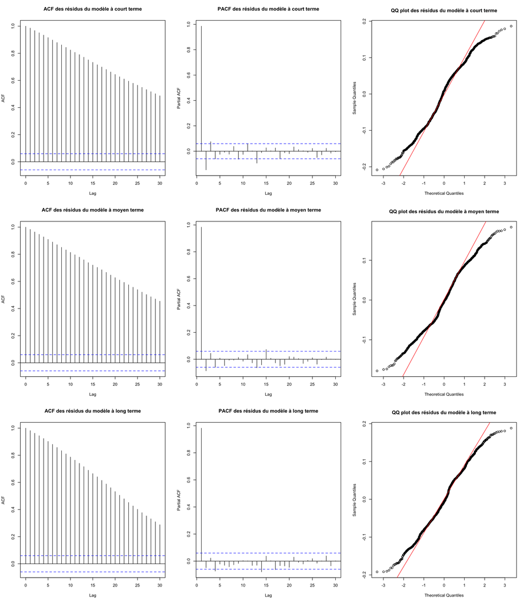

```r
layout(matrix(c(1, 2, 3, 4, 5, 6, 7, 8, 9), nrow = 3, byrow = TRUE))
acf(linear_model_short_term$residuals, main = "ACF des résidus du modèle à court terme")
pacf(linear_model_short_term$residuals, main = "PACF des résidus du modèle à court terme")
qqnorm(linear_model_short_term$residuals, main = "QQ plot des résidus du modèle à court terme"); qqline(linear_model_short_term$residuals, col = "red")
acf(linear_model_medium_term$residuals, main = "ACF des résidus du modèle à moyen terme")
pacf(linear_model_medium_term$residuals, main = "PACF des résidus du modèle à moyen terme")
qqnorm(linear_model_medium_term$residuals, main = "QQ plot des résidus du modèle à moyen terme"); qqline(linear_model_medium_term$residuals, col = "red")
acf(linear_model_long_term$residuals, main = "ACF des résidus du modèle à long terme")
pacf(linear_model_long_term$residuals, main = "PACF des résidus du modèle à long terme")
qqnorm(linear_model_long_term$residuals, main = "QQ plot des résidus du modèle à long terme"); qqline(linear_model_long_term$residuals, col = "red")
```

```r
par(mfrow = c(1, 1))
```

Tests statistiques pour les 3 modèles linéaires

```r
stargazer(
    linear_model_short_term, linear_model_medium_term, linear_model_long_term,
    type = "text",
    title = "Modèles linéaires avec différentiels de taux d'intérêt",
    column.labels = c("Modèle à court terme", "Modèle à moyen terme", "Modèle à long terme"),
    add.lines = list(

        c(
            "ADF Test p-value",
            round(adf.test(linear_model_short_term$residuals)$p.value, 4),
            round(adf.test(linear_model_medium_term$residuals)$p.value, 4),
            round(adf.test(linear_model_long_term$residuals)$p.value, 4)
        ),
        c(
            "Ljung-Box p-value",
            round(Box.test(linear_model_short_term$residuals, lag = 20, type = "Ljung-Box")$p.value, 4),
            round(Box.test(linear_model_medium_term$residuals, lag = 20, type = "Ljung-Box")$p.value, 4),
            round(Box.test(linear_model_long_term$residuals, lag = 20, type = "Ljung-Box")$p.value, 4)
        ),
        c(
            "ARCH Test p-value",
            round(Box.test(linear_model_short_term$residuals^2, lag = 12, type = "Ljung-Box")$p.value, 4),
            round(Box.test(linear_model_medium_term$residuals^2, lag = 12, type = "Ljung-Box")$p.value, 4),
            round(Box.test(linear_model_long_term$residuals^2, lag = 12, type = "Ljung-Box")$p.value, 4)
        ),
        c(
            "Jarque Bera Test p-value",
            round(jarque.bera.test(linear_model_short_term$residuals)$p.value, 4),
            round(jarque.bera.test(linear_model_medium_term$residuals)$p.value, 4),
            round(jarque.bera.test(linear_model_long_term$residuals)$p.value, 4)
        )
    )
)
```

```
##
## Modèles linéaires avec différentiels de taux d'intérêt
## =============================================================================================
##                                                      Dependent variable:
##                                 -------------------------------------------------------------
##                                                            eurusd
##                                 Modèle à court terme Modèle à moyen terme Modèle à long terme
##                                         (1)                  (2)                  (3)
## ---------------------------------------------------------------------------------------------
## diff_st                              -0.079***
##                                       (0.002)
##
## diff_mt                                                   -0.088***
##                                                            (0.002)
##
## diff_lt                                                                        -0.108***
##                                                                                 (0.003)
##
## Constant                              1.290***             1.312***            1.335***
##                                       (0.003)              (0.003)              (0.004)
##
## ---------------------------------------------------------------------------------------------
## ADF Test p-value                       0.0296               0.0356              0.0103
## Ljung-Box p-value                        0                    0                    0
## ARCH Test p-value                        0                    0                    0
## Jarque Bera Test p-value                 0                    0                    0
## Observations                           1,078                1,078                1,078
## R2                                     0.570                0.659                0.622
## Adjusted R2                            0.569                0.659                0.622
## Residual Std. Error (df = 1076)        0.085                0.076                0.080
## F Statistic (df = 1; 1076)          1,423.928***         2,083.406***        1,773.946***
## =============================================================================================
## Note:                                                             *p<0.1; **p<0.05; ***p<0.01
```

Pour les 3 modèles:

- Le p-value de T-test pour les coefficients beta sont inférieurs à 0.01, qui signifie que les différentiels de taux d’intérêt à court terme, moyen terme et long terme ont un effet significatif sur le taux de change EUR/USD.
- P-value du test ADF sont inférieurs à 0.05, ce qui suggère que les résidus de chaque modèle sont stationnaires.
- P-value de Test Ljung-Box sont inférieurs à 0.05, ce qui rejette l’hypothèse nulle d’absence d’autocorrélation des résidus, et suggère que les résidus de chaque modèle présentent une autocorrélation significative.
- P-value de test ARCH sont inférieurs à 0.05. La variance des résidus de chaque modèle n’est pas donc constante et il existe une hétéroscédasticité conditionnelle dans les résidus de chaque modèle.
- P-value de Jarque-Bera test sont inférieurs à 0.05, ce qui rejette l’hypothèse nulle de normalité des résidus.

Pour conclusion:

L’estimation MCO nous confirme un lien significatif entre les taux de change EUR/USD et les différentiels de taux d’intérêt à court terme, moyen terme et long terme, mais les modèles linéaires peuvent ne pas capturer toute la dynamique temporelle présente dans les données, et il peut être nécessaire d’ajouter d’autres variables, tels que des termes auto-régressifs ou de moyenne mobile pour améliorer la spécification du modèle et capturer l’autocorrélation présente dans les résidus.

Dans la partie suivante, on va utiliser le taux intérêt à moyen terme pour modéliser le taux de change EUR/USD. Ce taux d’intérêt à moyen terme est choisi car il a la corrélation la plus élevée avec le taux de change EUR/USD, et il a meilleur R2, qui indique une meilleure qualité d’ajustement que les autres différentiels de taux d’intérêt à court terme et long terme.

## Partie 3.2 : Combine les modèles

Dans cette partie, on va étudier l’impact de taux intérêt à moyen terme sur le taux de change EUR/USD, en combinant le modèle AR(1) et la régression linéaire entre les taux de change EUR/USD et les différentiels de taux d’intérêt à moyen terme (partie 3.1).

On teste donc un modèle à retards échelonnés (ADL) pour capturer l’effet dynamique du différentiel de taux d’intérêt à moyen terme sur le taux de change EUR/USD.
$$y_{(i,j),t} = \alpha_4 + \sum_{k=1}^{p} \gamma_k y_{(i,j),t-k} +
\beta_4 (r_{i,t-1} - r_{j,t-1}) + u_t$$

On prend en compte le délai d’une semaine en supposant que l’impact n’est pas immédiat, mais peut se faire sentir après une semaine, on ajoute donc les lags (1 semaine) de différentiels de taux d’intérêt à moyen terme.

Basé sur le modèle AR(1) que nous avons choisi dans la partie 1, on ajoute un lag de taux de change.

Cette spéfication de modèle peut être considéré comme un amélioration du modèle linéaire, en ajoutant les termes auto-régressifs pour capturer l’autocorrélation présente dans les résidus du modèle linéaire, et pour capturer la dynamique temporelle présente dans les données.

On teste la modèle à retards échelonnés (ADL) avec les différentiels de taux d’intérêt à moyen terme et les lags de taux de change EUR/USD.

```r
data <- data %>%
    mutate(
        # On ajoute le lag 1 du différentiel de taux d'intérêt à moyen terme :
        diff_mt_lag1 = lag(diff_mt, 1),
        # On ajoute le lag 1 du taux de change EUR/USD comme défini dans la première partie avec le modèle AR(1) :
        eurusd_lag1 = lag(eurusd, 1)
    )

# Estimation du modèle linéraire avec les variables retardées :
model_adl_mt <- lm(eurusd ~ diff_mt_lag1 + eurusd_lag1, data = data, na.action = na.omit)
print(summary(model_adl_mt))
```

```
##
## Call:
## lm(formula = eurusd ~ diff_mt_lag1 + eurusd_lag1, data = data,
##     na.action = na.omit)
##
## Residuals:
##       Min        1Q    Median        3Q       Max
## -0.062566 -0.006924  0.000200  0.007693  0.087510
##
## Coefficients:
##                Estimate Std. Error t value Pr(>|t|)
## (Intercept)   0.0171817  0.0068494   2.508   0.0123 *
## diff_mt_lag1 -0.0010990  0.0005629  -1.953   0.0511 .
## eurusd_lag1   0.9868338  0.0052046 189.608   <2e-16 ***
## ---
## Signif. codes:  0 '***' 0.001 '**' 0.01 '*' 0.05 '.' 0.1 ' ' 1
##
## Residual standard error: 0.01295 on 1074 degrees of freedom
##   (1 observation deleted due to missingness)
## Multiple R-squared:  0.9901, Adjusted R-squared:  0.9901
## F-statistic: 5.366e+04 on 2 and 1074 DF,  p-value: < 2.2e-16
```

En plus, le **p-value** de **T-test** du coefficient de lag de taux d’intérêt est **0,0511**, qui est légèrement supérieur à 0.05, ce qui suggère que l’effet du différentiel de taux d’intérêt à moyen terme avec un délai de 1 semaine sur le taux de change EUR/USD n’est pas statistiquement significatif à un niveau de 5%, mais il est proche du seuil de significativité.

Par contre, en prenant un niveau de significativité de 10%, on peut considérer que le différentiel de taux d’intérêt à moyen terme avec un délai de 1 semaine a un effet sur le taux de change EUR/USD.

On compare ce modèle ADL (combinaison du modèle AR(1) et modèle linéaire avec différentiels de taux d’intérêt à moyen terme) avec celle de AR(1) et celle linéaire avec différentiels de taux d’intérêt à moyen terme :

```r
stargazer(
    fit_arma, linear_model_medium_term, model_adl_mt,
    type = "text",
    title = "Comparaison du modèle à moyen terme et du modèle ADL",
    column.labels = c("Modèle AR(1)", "Modèle à moyen terme", "Modèle ADL"),
    add.lines = list(
        c(
            "Ljung-Box p-value",
            round(Box.test(fit_arma$residuals, lag = 20, type = "Ljung-Box")$p.value, 4),
            round(Box.test(linear_model_medium_term$residuals, lag = 20, type = "Ljung-Box")$p.value, 4),
            round(Box.test(model_adl_mt$residuals, lag = 20, type = "Ljung-Box")$p.value, 4)
        ),
        c(
            "ADF Test p-value",
            round(adf.test(fit_arma$residuals)$p.value, 4),
            round(adf.test(linear_model_medium_term$residuals)$p.value, 4),
            round(adf.test(model_adl_mt$residuals)$p.value, 4)
        ),
        c(
            "Jarque Bera Test p-value",
            round(jarque.bera.test(fit_arma$residuals)$p.value, 4),
            round(jarque.bera.test(linear_model_medium_term$residuals)$p.value, 4),
            round(jarque.bera.test(model_adl_mt$residuals)$p.value, 4)
        ),
        c(
            "ARCH Test p-value",
            round(Box.test(fit_arma$residuals^2, lag = 12, type = "Ljung-Box")$p.value, 4),
            round(Box.test(linear_model_medium_term$residuals^2, lag = 12, type = "Ljung-Box")$p.value, 4),
            round(Box.test(model_adl_mt$residuals^2, lag = 12, type = "Ljung-Box")$p.value, 4)
        )
    )
)
```

```
##
## Comparaison du modèle à moyen terme et du modèle ADL
## ==============================================================================================
##                                                   Dependent variable:
##                          ---------------------------------------------------------------------
##                                                 eurusd                       eurusd
##                             ARIMA                 OLS                         OLS
##                          Modèle AR(1)    Modèle à moyen terme              Modèle ADL
##                              (1)                  (2)                         (3)
## ----------------------------------------------------------------------------------------------
## ar1                        0.992***
##                            (0.004)
##
## ma1                        0.277***
##                            (0.031)
##
## intercept                  1.225***
##                            (0.054)
##
## diff_mt                                        -0.088***
##                                                 (0.002)
##
## diff_mt_lag1                                                                -0.001*
##                                                                             (0.001)
##
## eurusd_lag1                                                                 0.987***
##                                                                             (0.005)
##
## Constant                                       1.312***                     0.017**
##                                                 (0.003)                     (0.007)
##
## ----------------------------------------------------------------------------------------------
## Ljung-Box p-value           0.1978                 0                           0
## ADF Test p-value             0.01               0.0356                        0.01
## Jarque Bera Test p-value      0                    0                           0
## ARCH Test p-value             0                    0                           0
## Observations                1,078                1,078                       1,077
## R2                                               0.659                       0.990
## Adjusted R2                                      0.659                       0.990
## Log Likelihood            3,190.542
## sigma2                      0.0002
## Akaike Inf. Crit.         -6,373.084
## Residual Std. Error                        0.076 (df = 1076)           0.013 (df = 1074)
## F Statistic                           2,083.406*** (df = 1; 1076) 53,664.500*** (df = 2; 1074)
## ==============================================================================================
## Note:                                                              *p<0.1; **p<0.05; ***p<0.01
```

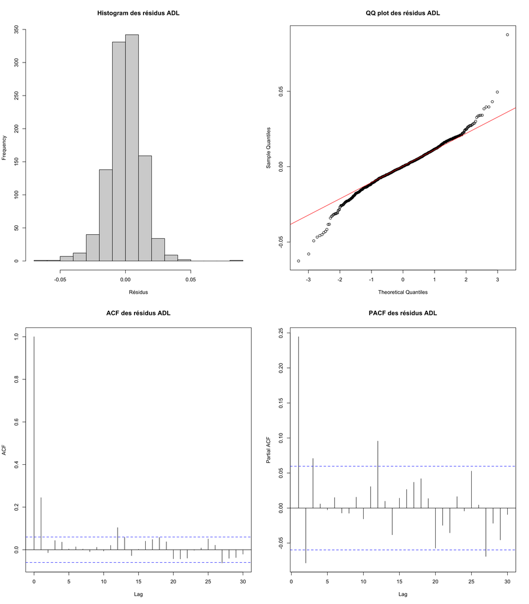

```r
residuals_adl_mt_weekly <- model_adl_mt$residuals

layout(matrix(c(1, 2, 3, 4), nrow = 2, byrow = TRUE))
hist(residuals_adl_mt_weekly, main = "Histogram des résidus ADL", xlab = "Résidus")
qqnorm(residuals_adl_mt_weekly, main = "QQ plot des résidus ADL"); qqline(residuals_adl_mt_weekly, col = "red")
acf(residuals_adl_mt_weekly, main = "ACF des résidus ADL")
pacf(residuals_adl_mt_weekly, main = "PACF des résidus ADL")
```

```r
# compute R2 of ARMA(1,1) model in 1st part
y_actual <- data$eurusd[]
y_pred_arma <- fitted(fit_arma)
u_hat <- residuals(fit_arma)
valid_indx <- !is.na(y_actual) & !is.na(y_pred_arma)
R2_arma <- 1 - sum(u_hat[valid_indx]^2) / sum((y_actual[valid_indx] - mean(y_actual[valid_indx]))^2)
print(paste("R2 of ARMA(1,1) model:", round(R2_arma, 4)))
```

```
## [1] "R2 of ARMA(1,1) model: 0.9907"
```

L’impact du différentiel de taux d’intérêt à moyen terme avec un délai de 1 semaine sur le taux de change EUR/USD n’est pas statistiquement significatif à un niveau de 5%, mais qu’au niveau de 10%.

En plus il est très faible par rapport à l’impact du lag de taux de change, et il n’explique pas une grande partie de la variation du taux de change EUR/USD.

Par contre, le score R2 du modèle ADL est beaucoup plus élevé que celui du modèle linéaire (0.990 vs 0.659), ça indique que une grande partie du taux de change EUR/USD est captée par les variables explicatives du modèle, en comparaison avec le modèle linéaire avec différentiels de taux d’intérêt à moyen terme seulement.

# Partie 4: Extension

Nous allons ajouter dans le modèle ADL la variable de différence de taux d’inflation entre Europe et les États-Unis.

$$y_{(i,j),t} = \alpha_4 + \sum_{k=1}^{p} \gamma_k y_{(i,j),t-k} +
\beta_4 (r_{i,t-1} - r_{j,t-1}) + \sum_{k=1}^{q} \zeta_k Z_{t-k} + u_t$$

où $Z_{t-k}$ est la différence de taux d’inflation entre l’Europe et les États-Unis avec un délai de k semaines.

D’après le modèle de la parité de pouvoir d’achat relative, les taux de change à long terme sont déterminés par les différentiels d’inflation entre les pays.

## Partie 4.1: Transformer les données hebdomadaires en mensuelles

Les données de taux d’inflation sont disponibles en granualité mensuelle, on va donc adapter notre fréquence de données en mensuelle.

Pour aligner avec les données utilisées dans les parties précédentes, on va calculer le taux de change mensuel et les différentiels de taux d’intérêt mensuels basé sur les données hebdomadaires.

```r
# Data montlhy exchange rate and interest rate
data_month <- data %>%
    arrange(date) %>%
    mutate(month = floor_date(date, "month")) %>%
    group_by(month) %>%
    summarise(
        # For exchange rate, get the last observation of each month
        eurusd = last(na.omit(eurusd)),

        # for interest rate differentials, get the mean of each month
        ct_us = mean(ct_us, na.rm = TRUE),
        mt_us = mean(mt_us, na.rm = TRUE),
        lt_us = mean(lt_us, na.rm = TRUE),
        ct_eur = mean(ct_eur, na.rm = TRUE),
        mt_eur = mean(mt_eur, na.rm = TRUE),
        lt_eur = mean(lt_eur, na.rm = TRUE),
        .groups = "drop"
    )
data_month <- data_month %>%
    mutate(
        date = month,
        diff_eurusd = eurusd / lag(eurusd) - 1,
        diff_st = ct_eur - ct_us,
        diff_mt = mt_eur - mt_us,
        diff_lt = lt_eur - lt_us
    )

adf.test(data_month$eurusd)
```

```
##
##  Augmented Dickey-Fuller Test
##
## data:  data_month$eurusd
## Dickey-Fuller = -3.6215, Lag order = 6, p-value = 0.03157
## alternative hypothesis: stationary
```

D’après le test ADF, le p value est inférieur à 0.05, ce qui suggère que le taux de change EUR/USD en données mensuelles est stationnaire.

On choisit donc le taux de change pour la modélisation, car il est stationnaire.

## Partie 4.2: Identification du lag de la variable taux de change

```r
# Refit ARMA model with monthly data
p_max <- 5
q_max <- 5
results_monthly_arma <- data.frame(p = integer(), q = integer(), AIC = numeric(), BIC = numeric())
k <- 1
for (p in 0:p_max) {
    for (q in 0:q_max) {
        fit <- try(arima(data_month$eurusd, order = c(p, 0, q)), silent = TRUE)
        if (class(fit) != "try-error") {
            results_monthly_arma[k, ] <- data.frame(p = p, q = q, AIC = AIC(fit), BIC = BIC(fit))
        }
        k <- k + 1
    }
}
table_results_month <- do.call(rbind, lapply(1:nrow(results_monthly_arma), function(i) {
    if (!is.na(results_monthly_arma$AIC[i]) & !is.na(results_monthly_arma$BIC[i])) {
        data.frame(p = results_monthly_arma$p[i], q = results_monthly_arma$q[i], AIC = results_monthly_arma$AIC[i], BIC = results_monthly_arma$BIC[i])
    }
}))
# Find minimum values for AIC and BIC
table_results_month <- table_results_month %>% drop_na()
table_results_month$delta_BIC <- table_results_month$BIC - min(table_results_month$BIC)
table_BIC_month <- table_results_month[order(table_results_month$BIC), ]
print("Top 5 models based on BIC:")
```

```
## [1] "Top 5 models based on BIC:"
```

```r
print(head(table_BIC_month, 5))
```

```
##    p q       AIC        BIC delta_BIC
## 7  1 0 -1018.357 -1007.7219  0.000000
## 13 2 0 -1016.372 -1002.1909  5.530931
## 8  1 1 -1016.371 -1002.1899  5.531968
## 17 2 4 -1028.787 -1000.4259  7.296013
## 25 4 0 -1019.422  -998.1509  9.571006
```

```r
data_month <- data_month %>%
    mutate(
        eurusd_lag1 = lag(eurusd, 1),
    )
```

## Partie 4.3: Identification la variable taux d’intérêt pour la modélisation

On compare ensuite les trois séries de taux d’intérêt (CT, MT, LT) avec le fit de modèle linéaire, afin de déterminer la meilleure série à utiliser dans notre modèle.

```r
lm_st_monthly <- lm(eurusd ~ diff_st, data = data_month)
lm_mt_monthly <- lm(eurusd ~ diff_mt, data = data_month)
lm_lt_monthly <- lm(eurusd ~ diff_lt, data = data_month)

stargazer(
    lm_st_monthly, lm_mt_monthly, lm_lt_monthly,
    type = "text",
    title = "Linear Models with Monthly Interest Rate Differentials",
    column.labels = c("Short term Model", "Medium term Model", "Long term Model"),
    add.lines = list(
        c(
            "Ljung-Box p-value",
            round(Box.test(lm_st_monthly$residuals, lag = 20, type = "Ljung-Box")$p.value, 4),
            round(Box.test(lm_mt_monthly$residuals, lag = 20, type = "Ljung-Box")$p.value, 4),
            round(Box.test(lm_lt_monthly$residuals, lag = 20, type = "Ljung-Box")$p.value, 4)
        ),
        c(
            "ADF Test p-value",
            round(adf.test(lm_st_monthly$residuals)$p.value, 4),
            round(adf.test(lm_mt_monthly$residuals)$p.value, 4),
            round(adf.test(lm_lt_monthly$residuals)$p.value, 4)
        ),
        c(
            "Jarque Bera Test p-value",
            round(jarque.bera.test(lm_st_monthly$residuals)$p.value, 4),
            round(jarque.bera.test(lm_mt_monthly$residuals)$p.value, 4),
            round(jarque.bera.test(lm_lt_monthly$residuals)$p.value, 4)
        ),
        c(
            "ARCH Test p-value",
            round(Box.test(lm_st_monthly$residuals^2, lag = 12, type = "Ljung-Box")$p.value, 4),
            round(Box.test(lm_mt_monthly$residuals^2, lag = 12, type = "Ljung-Box")$p.value, 4),
            round(Box.test(lm_lt_monthly$residuals^2, lag = 12, type = "Ljung-Box")$p.value, 4)
        )
    )
)
```

```
##
## Linear Models with Monthly Interest Rate Differentials
## =================================================================================
##                                               Dependent variable:
##                                --------------------------------------------------
##                                                      eurusd
##                                Short term Model Medium term Model Long term Model
##                                      (1)               (2)              (3)
## ---------------------------------------------------------------------------------
## diff_st                            0.079***
##                                    (0.004)
##
## diff_mt                                             0.089***
##                                                      (0.004)
##
## diff_lt                                                              0.110***
##                                                                       (0.005)
##
## Constant                           1.290***         1.313***         1.337***
##                                    (0.007)           (0.006)          (0.007)
##
## ---------------------------------------------------------------------------------
## Ljung-Box p-value                     0                 0                0
## ADF Test p-value                    0.0102            0.01             0.01
## Jarque Bera Test p-value            0.0111            0.013            0.061
## ARCH Test p-value                     0                 0                0
## Observations                         256               256              256
## R2                                  0.561             0.657            0.629
## Adjusted R2                         0.559             0.656            0.628
## Residual Std. Error (df = 254)      0.087             0.077            0.080
## F Statistic (df = 1; 254)         324.652***       487.241***       430.864***
## =================================================================================
## Note:                                                 *p<0.1; **p<0.05; ***p<0.01
```

On choisit donc le taux intérêt à long terme pour la modèle ADL.

```r
data_month <- data_month %>%
    mutate(
        diff_lt_lag1 = lag(diff_lt, 1)
    )
data_month <- data_month %>%
    drop_na()
```

## Partie 4.4: Identification le lag de variable d’inflation pour la modélisation

On calcule le taux d’inflation mensuel pour les États-Unis et l’Europe, en utilisant les données de l’indice des prix à la consommation (CPI) pour les États-Unis et l’indice des prix à la consommation harmonisé (HICP) pour l’Europe. L’inflation sera calculée comme la différence logarithmique de l’indice des prix sur les 12 mois glissants, ce qui correspond à une mesure d’inflation annuelle.

```r
data_inflation_us <- read.csv("Econometrics/data/CPI_US.csv") %>%
    rename(date = names(.)[1], CPI = names(.)[2]) %>%
    mutate(
        date = as.Date(date),
        inflation_us = log(CPI) - log(lag(CPI, 12))
    )
data_inflation_eur <- read.csv("Econometrics/data/HICP_EU.csv") %>%
    rename(date = names(.)[1], HICP = names(.)[2]) %>%
    mutate(
        date = as.Date(date),
        inflation_eur = log(HICP) - log(lag(HICP, 12))
    )

# merge with data month
data_month <- data_month %>%
    inner_join(data_inflation_us %>% select(date, inflation_us), by = "date") %>%
    inner_join(data_inflation_eur %>% select(date, inflation_eur), by = "date") %>%
    mutate(
        diff_inflation = inflation_eur - inflation_us
    )
print(head(data_month))
```

```
## # A tibble: 6 × 18
##   month      eurusd ct_us mt_us lt_us ct_eur mt_eur lt_eur date
##   <date>      <dbl> <dbl> <dbl> <dbl>  <dbl>  <dbl>  <dbl> <date>
## 1 2004-10-01   1.28  1.75  2.58  4.09   2.06   2.47   4.00 2004-10-01
## 2 2004-11-01   1.31  2.06  2.84  4.18   2.09   2.41   3.89 2004-11-01
## 3 2004-12-01   1.36  2.19  3.02  4.24   2.09   2.39   3.67 2004-12-01
## 4 2005-01-01   1.30  2.33  3.22  4.23   2.05   2.39   3.59 2005-01-01
## 5 2005-02-01   1.32  2.53  3.38  4.16   2.05   2.43   3.59 2005-02-01
## 6 2005-03-01   1.34  2.71  3.66  4.44   2.05   2.45   3.75 2005-03-01
## # ℹ 9 more variables: diff_eurusd <dbl>, diff_st <dbl>, diff_mt <dbl>,
## #   diff_lt <dbl>, eurusd_lag1 <dbl>, diff_lt_lag1 <dbl>, inflation_us <dbl>,
## #   inflation_eur <dbl>, diff_inflation <dbl>
```

Ensuite on essaie différents lags de la variable de différence d’inflation pour trouver le lag optimal pour la modélisation.

On réalise T-test pour les coefficients de différentiels d’inflation avec différents lags, et on choisit le lag qui a un effet significatif sur le taux de change EUR/USD,

```r
max_inflation_lag <- 10

for (lag in 1:max_inflation_lag) {
    data_month <- data_month %>%
        mutate(!!paste0("diff_inflation_lag", lag) := lag(diff_inflation, lag))
}
```

```r
# T-test pour les coefficients de différentiels d'inflation avec différents lags
result_table_inflation_lag_t_test <- data.frame(
    lag = integer(),
    t_value = numeric(),
    p_value = numeric()
)

for (lag in 1:max_inflation_lag) {
    formula_q <- as.formula(paste("eurusd ~ diff_lt_lag1 + eurusd_lag1 + diff_inflation_lag", lag, sep = ""))
    model_adl_inflation <- lm(formula_q, data = data_month, na.action = na.omit)
    print(summary(model_adl_inflation))
    result_table_inflation_lag_t_test <- rbind(result_table_inflation_lag_t_test, data.frame(
        lag = lag,
        t_value = round(summary(model_adl_inflation)$coefficients[paste0("diff_inflation_lag", lag), "t value"], 4),
        p_value = round(summary(model_adl_inflation)$coefficients[paste0("diff_inflation_lag", lag), "Pr(>|t|)"], 4)
    ))
}
```

```
##
## Call:
## lm(formula = formula_q, data = data_month, na.action = na.omit)
##
## Residuals:
##      Min       1Q   Median       3Q      Max
## -0.19012 -0.01397  0.00166  0.01856  0.10403
##
## Coefficients:
##                     Estimate Std. Error t value Pr(>|t|)
## (Intercept)         0.058666   0.038805   1.512    0.132
## diff_lt_lag1        0.002845   0.004178   0.681    0.497
## eurusd_lag1         0.956295   0.029088  32.876   <2e-16 ***
## diff_inflation_lag1 0.576565   0.248235   2.323    0.021 *
## ---
## Signif. codes:  0 '***' 0.001 '**' 0.01 '*' 0.05 '.' 0.1 ' ' 1
##
## Residual standard error: 0.0321 on 250 degrees of freedom
##   (1 observation deleted due to missingness)
## Multiple R-squared:  0.9416, Adjusted R-squared:  0.9409
## F-statistic:  1342 on 3 and 250 DF,  p-value: < 2.2e-16
##
##
## Call:
## lm(formula = formula_q, data = data_month, na.action = na.omit)
##
## Residuals:
##       Min        1Q    Median        3Q       Max
## -0.189741 -0.015394  0.000356  0.018226  0.111930
##
## Coefficients:
##                     Estimate Std. Error t value Pr(>|t|)
## (Intercept)         0.070957   0.037195   1.908   0.0576 .
## diff_lt_lag1        0.004020   0.004021   1.000   0.3184
## eurusd_lag1         0.946719   0.027834  34.013   <2e-16 ***
## diff_inflation_lag2 0.469536   0.237634   1.976   0.0493 *
## ---
## Signif. codes:  0 '***' 0.001 '**' 0.01 '*' 0.05 '.' 0.1 ' ' 1
##
## Residual standard error: 0.03217 on 249 degrees of freedom
```

[output cut: 164 more lines]

```
## -0.196176 -0.015312  0.001507  0.017336  0.107017
##
## Coefficients:
##                       Estimate Std. Error t value Pr(>|t|)
## (Intercept)           0.095396   0.034339   2.778   0.0059 **
## diff_lt_lag1          0.007549   0.003552   2.126   0.0346 *
## eurusd_lag1           0.927936   0.025571  36.288   <2e-16 ***
## diff_inflation_lag10 -0.087490   0.211712  -0.413   0.6798
## ---
## Signif. codes:  0 '***' 0.001 '**' 0.01 '*' 0.05 '.' 0.1 ' ' 1
##
## Residual standard error: 0.03232 on 241 degrees of freedom
##   (10 observations deleted due to missingness)
## Multiple R-squared:  0.9421, Adjusted R-squared:  0.9414
## F-statistic:  1307 on 3 and 241 DF,  p-value: < 2.2e-16
```

```r
print("Résultats du T-test pour les coefficients de différentiels d'inflation avec différents lags:")
```

```
## [1] "Résultats du T-test pour les coefficients de différentiels d'inflation avec différents lags:"
```

```r
print(result_table_inflation_lag_t_test)
```

```
##    lag t_value p_value
## 1    1  2.3227  0.0210
## 2    2  1.9759  0.0493
## 3    3  2.0334  0.0431
## 4    4  1.6633  0.0975
## 5    5  1.2604  0.2087
## 6    6  1.3792  0.1691
## 7    7  0.5487  0.5837
## 8    8 -0.0644  0.9487
## 9    9  0.0243  0.9807
## 10  10 -0.4133  0.6798
```

D’après les résultats du T-test, on voit que entre lag 1 et 3, les coefficients de différentiels d’inflation sont significatifs (p-value < 0.05).

A partir du lag 4, les lags de la variable de différence d’inflation n’ont pas d’effet significatif sur le taux de change EUR/USD.

On réalise l’évaluation du modèle avec différents lags de la variable de différence d’inflation, en utilisant les critères AIC, BIC, R2, R2 ajusté et le test de Ljung-Box pour l’autocorrélation des résidus.

```r
# Evaluation du modèle avec différents lags de la variable de différence d'inflation
result_table_inflation_lag <- data.frame(
    lag = integer(),
    AIC = numeric(),
    BIC = numeric(),
    R2 = numeric(),
    R2_adj = numeric(),
    Ljung_Box_p_value = numeric()
)
for (lag in 1:max_inflation_lag) {

    terms <- paste0("diff_inflation_lag", 1:lag, collapse = " + ")
    formula_q <- as.formula(paste("eurusd ~ diff_lt_lag1 + eurusd_lag1 +", terms))
    model_adl_inflation <- lm(formula_q, data = data_month, na.action = na.omit)
    result_table_inflation_lag <- rbind(result_table_inflation_lag, data.frame(
        lag = lag,
        AIC = AIC(model_adl_inflation),
        BIC = BIC(model_adl_inflation),
        R2 = summary(model_adl_inflation)$r.squared,
        R2_adj = summary(model_adl_inflation)$adj.r.squared,
        Ljung_Box_p_value = round(Box.test(model_adl_inflation$residuals, lag = 20, type = "Ljung-Box")$p.value, 4)
    ))
}

result_table_inflation_lag <- result_table_inflation_lag %>%
    mutate(delta_BIC = BIC - min(BIC)) %>%
    arrange(BIC)

print("Résultats de l'estimation du modèle ADL avec différents lags de la variable de différence d'inflation:")
```

```
## [1] "Résultats de l'estimation du modèle ADL avec différents lags de la variable de différence d'inflation:"
```

```r
print(result_table_inflation_lag)
```

```
##    lag        AIC        BIC        R2    R2_adj Ljung_Box_p_value delta_BIC
## 1    1 -1020.2348 -1002.5482 0.9415537 0.9408524            0.0264  0.000000
## 2    2 -1015.0841  -993.8838 0.9418877 0.9409504            0.0235  8.664405
## 3    3 -1012.1038  -987.3978 0.9425859 0.9414189            0.0643 15.150355
## 4    4 -1008.1106  -979.9070 0.9432069 0.9418104            0.0930 22.641177
## 5    5 -1001.9968  -970.3036 0.9433054 0.9416654            0.1046 32.244538
## 6    6  -996.8159  -961.6414 0.9435760 0.9416952            0.1553 40.906779
## 7    7  -996.2649  -957.6172 0.9449796 0.9428990            0.2592 44.930972
## 8    8  -989.8291  -947.7165 0.9451143 0.9427886            0.2543 54.831696
## 9    9  -987.0657  -941.4964 0.9460719 0.9435368            0.3047 61.051739
## 10  10  -981.6786  -932.6610 0.9464477 0.9436778            0.3343 69.887206
```

On préfère donc choisir le modèle avec lag jusqu’à 3, qui a un meilleur équilibre entre la qualité d’ajustement et la parsimony du modèle.

$$y_{(i,j),t} = \alpha_4 + \gamma_k y_{(i,j),t-1} + \beta_4 (r_{i,t-1}
- r_{j,t-1}) + \sum_{k=1}^{3} \zeta_k Z_{t-k} + u_t$$

```r
# Fit ARMA model
best_model_month <- table_BIC_month[1, ]
print(paste("Best ARMA model for monthly data: ARMA(", best_model_month$p, ",", best_model_month$q, ")", sep = ""))
```

```
## [1] "Best ARMA model for monthly data: ARMA(1,0)"
```

```r
fit_arma_month <- arima(data_month$eurusd, order = c(best_model_month$p, 0, best_model_month$q), include.mean = TRUE, method = "ML")
#Fit linear moodel with instant rate differential
lm_lt_monthly_instant <- lm(eurusd ~ diff_lt, data = data_month)
# Fit linear model with lagged rate differential
lm_lt_monthly_lagged <- lm(eurusd ~ diff_lt_lag1, data = data_month)

# Fit ADL model with lagged rate differential and lagged exchange rate
model_adl_lt <- lm(eurusd ~ diff_lt_lag1 + eurusd_lag1, data = data_month)

# Fit ADL model with lagged rate differential, lagged exchange rate and lagged inflation differential (up to lag 3)
model_adl_lt_inflation <- lm(
    eurusd ~ diff_lt_lag1 + eurusd_lag1 + diff_inflation_lag1 + diff_inflation_lag2 + diff_inflation_lag3,
    data = data_month
)
```

```r
stargazer(
    fit_arma_month, lm_lt_monthly_instant, lm_lt_monthly_lagged,
    type = "text",
    title = "Comparison of Models with Monthly Data",
    column.labels = c("ARMA Model", "Linear Instant Model", "Linear Lagged Model"),
    add.lines = list(
        c(
            "Ljung-Box p-value",
            round(Box.test(fit_arma_month$residuals, lag = 20, type = "Ljung-Box")$p.value, 4),
            round(Box.test(lm_lt_monthly_instant$residuals, lag = 20, type = "Ljung-Box")$p.value, 4),
            round(Box.test(lm_lt_monthly_lagged$residuals, lag = 20, type = "Ljung-Box")$p.value, 4)
        ),
        c(
            "ADF Test p-value",
            round(adf.test(fit_arma_month$residuals)$p.value, 4),
            round(adf.test(lm_lt_monthly_instant$residuals)$p.value, 4),
            round(adf.test(lm_lt_monthly_lagged$residuals)$p.value, 4)
        ),
        c(
            "Jarque Bera Test p-value",
            round(jarque.bera.test(fit_arma_month$residuals)$p.value, 4),
            round(jarque.bera.test(lm_lt_monthly_instant$residuals)$p.value, 4),
            round(jarque.bera.test(lm_lt_monthly_lagged$residuals)$p.value, 4)
        ),
        c(
            "ARCH Test p-value",
            round(Box.test(fit_arma_month$residuals^2, lag = 12, type = "Ljung-Box")$p.value, 4),
            round(Box.test(lm_lt_monthly_instant$residuals^2, lag = 12, type = "Ljung-Box")$p.value, 4),
            round(Box.test(lm_lt_monthly_lagged$residuals^2, lag = 12, type = "Ljung-Box")$p.value, 4)
        )
    )
)
```

```
##
## Comparison of Models with Monthly Data
## ==================================================================================
##                                                Dependent variable:
##                                ---------------------------------------------------
##                                                  eurusd              eurusd
##                                  ARIMA            OLS                  OLS
##                                ARMA Model Linear Instant Model Linear Lagged Model
##                                   (1)             (2)                  (3)
## ----------------------------------------------------------------------------------
## ar1                              1.000
##
##
## intercept                        1.226
##
##
## diff_lt                                         0.111***
##                                                 (0.005)
##
## diff_lt_lag1                                                        0.110***
##                                                                      (0.005)
##
## Constant                                        1.338***            1.336***
##                                                 (0.007)              (0.007)
##
## ----------------------------------------------------------------------------------
## Ljung-Box p-value                0.0032            0                    0
## ADF Test p-value                  0.01            0.01                0.01
## Jarque Bera Test p-value           0             0.0674              0.1503
## ARCH Test p-value                  0               0                    0
## Observations                      255             255                  255
## R2                                               0.632                0.626
## Adjusted R2                                      0.630                0.625
## Log Likelihood                  509.752
## sigma2                           0.001
## Akaike Inf. Crit.              -1,013.505
## Residual Std. Error (df = 253)                   0.080                0.081
## F Statistic (df = 1; 253)                      434.016***          424.130***
## ==================================================================================
## Note:                                                  *p<0.1; **p<0.05; ***p<0.01
```

```r
stargazer(
    model_adl_lt, model_adl_lt_inflation,
    type = "text",
    title = "Comparaison de modèles avec données mensuelles",
    column.labels = c("Modèle ADL", "Modèle ADL avec différentiel d'inflation"),
    add.lines = list(
        c(
            "Ljung-Box p-value",
            round(Box.test(model_adl_lt$residuals, lag = 20, type = "Ljung-Box")$p.value, 4),
            round(Box.test(model_adl_lt_inflation$residuals, lag = 20, type = "Ljung-Box")$p.value, 4)
        ),
        c(
            "ADF Test p-value",
            round(adf.test(model_adl_lt$residuals)$p.value, 4),
            round(adf.test(model_adl_lt_inflation$residuals)$p.value, 4)
        ),
        c(
            "Jarque Bera Test p-value",
            round(jarque.bera.test(model_adl_lt$residuals)$p.value, 4),
            round(jarque.bera.test(model_adl_lt_inflation$residuals)$p.value, 4)
        ),
        c(
            "ARCH Test p-value",
            round(Box.test(model_adl_lt$residuals^2, lag = 12, type = "Ljung-Box")$p.value, 4),
            round(Box.test(model_adl_lt_inflation$residuals^2, lag = 12, type = "Ljung-Box")$p.value, 4)
        )
    )
)
```

```
##
## Comparaison de modèles avec données mensuelles
## ============================================================================================
##                                                  Dependent variable:
##                          -------------------------------------------------------------------
##                                                        eurusd
##                                  Modèle ADL         Modèle ADL avec différentiel d'inflation
##                                     (1)                               (2)
## --------------------------------------------------------------------------------------------
## diff_lt_lag1                      0.009**                            0.002
##                                   (0.004)                           (0.004)
##
## eurusd_lag1                       0.920***                          0.962***
##                                   (0.025)                           (0.029)
##
## diff_inflation_lag1                                                  1.180*
##                                                                     (0.624)
##
## diff_inflation_lag2                                                  -1.134
##                                                                     (0.934)
##
## diff_inflation_lag3                                                  0.635
##                                                                     (0.592)
##
## Constant                          0.107***                           0.050
##                                   (0.034)                           (0.039)
##
## --------------------------------------------------------------------------------------------
## Ljung-Box p-value                  0.0119                            0.0643
## ADF Test p-value                    0.01                              0.01
## Jarque Bera Test p-value             0                                 0
## ARCH Test p-value                    0                                 0
## Observations                        255                               252
## R2                                 0.940                             0.943
## Adjusted R2                        0.939                             0.941
## Residual Std. Error           0.032 (df = 252)                  0.032 (df = 246)
## F Statistic              1,971.038*** (df = 2; 252)         807.732*** (df = 5; 246)
## ============================================================================================
## Note:                                                            *p<0.1; **p<0.05; ***p<0.01
```

Mais avec l’ajout de la variable de différence de taux d’inflation, on a une amélioration du p-value de test de Ljung-Box. On a pu donc éliminer l’autocorrélation des résidus du modèle ADL avec les données mensuelles, en échange avec la pénalisation du BIC.

#### Conclusion:

En ajoutant la variable de différence de taux d’inflation entre l’Europe et les États-Unis dans le modèle ADL nous a permis d’enlever l’autocorrélation présentée dans les résidus du modèle ADL sans la variable d’inflation.

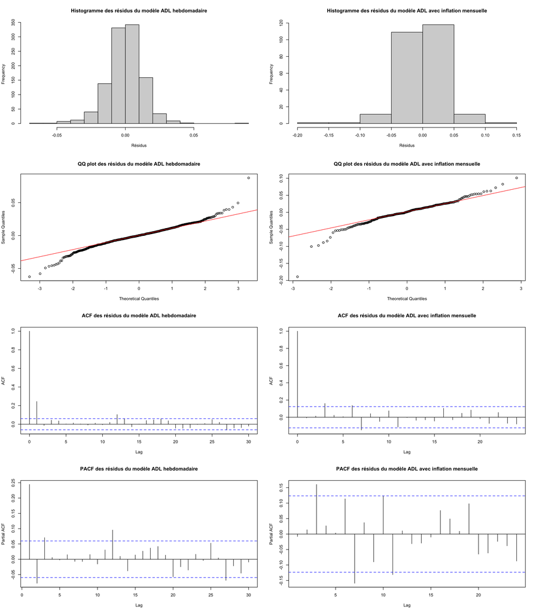

```r
residuals_adl_mt_weekly <- model_adl_mt$residuals
residuals_adl_lt <- model_adl_lt$residuals
residuals_adl_lt_inflation <- model_adl_lt_inflation$residuals

layout(matrix(c(1, 2, 3, 4, 5, 6, 7, 8), nrow = 4, byrow = TRUE))
hist(residuals_adl_mt_weekly, main = "Histogramme des résidus du modèle ADL hebdomadaire", xlab = "Résidus")
hist(residuals_adl_lt_inflation, main = "Histogramme des résidus du modèle ADL avec inflation mensuelle", xlab = "Résidus")
qqnorm(residuals_adl_mt_weekly, main = "QQ plot des résidus du modèle ADL hebdomadaire"); qqline(residuals_adl_mt_weekly, col = "red")
qqnorm(residuals_adl_lt_inflation, main = "QQ plot des résidus du modèle ADL avec inflation mensuelle"); qqline(residuals_adl_lt_inflation, col = "red")
acf(residuals_adl_mt_weekly, main = "ACF des résidus du modèle ADL hebdomadaire")
acf(residuals_adl_lt_inflation, main = "ACF des résidus du modèle ADL avec inflation mensuelle")
pacf(residuals_adl_mt_weekly, main = "PACF des résidus du modèle ADL hebdomadaire")
pacf(residuals_adl_lt_inflation, main = "PACF des résidus du modèle ADL avec inflation mensuelle")
```

Le résultat montre que l’utilisation des données mensuelles et l’ajout de la variable de différence de taux d’inflation entre l’Europe et les États-Unis dans le modèle ADL a amélioré la qualité d’ajustement du modèle, comme indiqué par l’augmentation p-value de test Ljung-Box vis-à-vis le modèle ADL sans cette variable.

Par contre, les résidus du modèle ADL avec la variable d’inflation présentent toujours une hétéroscédasticité conditionnelle, comme indiqué par le test ARCH.

# Partie 5: Conclusion

D’après plusieurs tests, on peut conclure que la relation entre le taux de change et les différentiels de taux d’intérêt n’est pas évidente, ce qui est cohérent avec la littérature empirique qui montre que la parité des taux d’intérêt non couverte est souvent violée, en raison de l’existence de primes de risque, des comportements spéculatifs et/ou irrationnels, et des restrictions de capitaux dans certains pays.